# Solutions 8 : Parser des documents balisés avec `lxml` et BeautifulSoup

**Loïc Grobol** lgrobol@parisnanterre.fr

2021-10-06

```python
from IPython.display import display
```

```python
%pip install -U beautifulsoup4 lxml matplotlib requests
```

```python
from bs4 import BeautifulSoup
import lxml
import requests
```

```python
import requests
from bs4 import BeautifulSoup

url = "http://web.archive.org/web/20180430090903/http://songx.se/index.php" # le lien vers le site
html = requests.get(url) # on récupère le contenu
soup = BeautifulSoup(html.text, 'lxml') # on crée un objet pour traiter la page
```

## 🎶 Exo 1 🎶

1. Affichez les titres et les tunings des 10 premières chansons en utilisant la méthode [`find_all`](https://www.crummy.com/software/BeautifulSoup/bs4/doc/#find-all). La méthode renvoie un itérable.

```python
for item in soup.find_all('div', attrs={'class':'songrow'})[:10]:
    print(item.a.string, item.div.string)
```

```
1956 Bubblegum Disaster EADGBE
A Dream That Can Last EADGBE
A Man Needs A Maid EADGBE
A Man Needs A Maid/Heart Of Gold (Suite) EADGBE
A New Day For Love EADGBE
A Rock Star Bucks A Coffee Shop EADGBE
Act Of Love EADGBE
After Berlin DADGBD
After The Garden EADGBE
After The Gold Rush EADGBE
```

On peut aussi utiliser la notation suivante

```python
for item in soup.find_all('div', class_="songrow")[:10]:
    print(item.a.string, item.div.string)
```

```
1956 Bubblegum Disaster EADGBE
A Dream That Can Last EADGBE
A Man Needs A Maid EADGBE
A Man Needs A Maid/Heart Of Gold (Suite) EADGBE
A New Day For Love EADGBE
A Rock Star Bucks A Coffee Shop EADGBE
Act Of Love EADGBE
After Berlin DADGBD
After The Garden EADGBE
After The Gold Rush EADGBE
```

2. Créez un `dict` appelé `tunings` qui classe les chansons par tuning (autrement dit qui associe à un tuning la liste des morceaux qui l'utilisent). (On peut utiliser plus sympa qu'un bête `dict`). Lisez bien la doc de [`find_all`](https://www.crummy.com/software/BeautifulSoup/bs4/doc/index.html#find-all)

```python
from collections import defaultdict
tunings = defaultdict(list)
for item in soup.find_all('div', class_="songrow"):
    song_title = item.a.string
    tuning = item.div.string
    tunings[tuning].append(song_title)
tunings = dict(tunings)
```

3. 'Harvest Moon' utilise l'accordage DADGBE, y en a-t'il d'autres ?

```python
tunings["DADGBE"]
```

```
['Albuquerque',
 'Angry World',
 'Captain Kennedy',
 "Daddy Went Walkin'",
 'Dirty Old Man',
 'Give Me Strength',
 'Harvest Moon',
 'Hawaii',
 'He Was The King',
 'Homegrown',
 'Like An Inca',
 'Live To Ride',
 'New Mama',
 'Night Song',
 'Ohio',
 'Prime Of Life',
 'Silver & Gold',
 'Sleeps With Angels',
 'Star Of Betlehem',
 'The Ways Of Love',
 "Tonight's The Night",
 'World On A String',
 'You And Me']
```

4. Affichez les accordages et le nombre de chansons pour chaque accordage, le tout trié par nombre de chansons décroissant. Pour cela, cous utiliserez la méthode `sorted` ainsi que l'argument mot-clé `key` (des exemples [ici](https://wiki.python.org/moin/HowTo/Sorting#Key_Functions)) :

```python
n_songs = ((tuning, len(songs)) for tuning, songs in tunings.items())
for tuning, n in sorted(n_songs, key=lambda x: -x[1]):
    print(f"{tuning}: {n}")
```

```
EADGBE: 475
DADGBD: 30
DADGBE: 23
DGCFAD: 23
CGCFAC: 2
CGCFAD: 2
EbAbDbGbBb: 1
BbFBbEbGBb: 1
DGCFAA: 1
```

Ou alors

```python
n_songs = ((tuning, len(songs)) for tuning, songs in tunings.items())
for tuning, n in sorted(n_songs, key=lambda x: x[1], reverse=True):
    print(f"{tuning}: {n}")
```

```
EADGBE: 475
DADGBD: 30
DADGBE: 23
DGCFAD: 23
CGCFAC: 2
CGCFAD: 2
EbAbDbGbBb: 1
BbFBbEbGBb: 1
DGCFAA: 1
```

Allez hop un histogramme

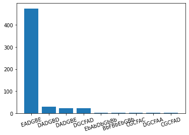

```python
%matplotlib inline
import matplotlib.pyplot as plt
values = [len(tunings[x]) for x in tunings]
values
plt.bar(range(0, len(values)), values)
plt.xticks(range(0, len(values)), tunings.keys(), rotation=17)

plt.show()
```

5. Une chanson a un tuning un peu particulier comparé aux autres (indice, c'est une question de taille). Trouvez le tuning qui est différent des autres et donnez la chanson qui lui correspond. *Attention*, "b" signifie "bémol", il ne s'agit pas d'une note pour l'accordage (contrairement à A, B, C, D, E, F et G) !

```python
[t for t in tunings.keys() if len([c for c in t if c.isupper()]) != 6]
```

```
['EbAbDbGbBb']
```

## Parser du XML

Nous allons travailler sur un fichier au format [TEI](http://www.tei-c.org/) extrait du corpus [*Corpus 14*](https://hdl.handle.net/11403/corpus14/v1).

Le fichier se nomme `josephine-1-150119.xml`. Il s'agit d'une lettre d'une femme de soldat à son époux. Les chemins du notebook devraient fonctionner sur Binder, pour bosser en local, vous pouvez le récupérer sur [GitHub](https://raw.githubusercontent.com/LoicGrobol/web-interfaces/main/data/josephine-1-150119.xml)

Nous allons extraire du fichier TEI les informations suivantes :

- titre (`/TEI/teiHeader/fileDesc/titleStmt/title`)
- source (`/TEI/teiHeader/fileDesc/sourceDesc/p`)
- contenu de la lettre (`/TEI/text/body`)

Vous pouvez trouver des indications sur les éléments de la TEI [ici](http://www.tei-c.org/release/doc/tei-p5-doc/fr/html/) (ça pourra être utile pour les questions)

### Avec lxml

Pourquoi `lxml` et pas `xml.etree.ElementTree` ? Parce que : [1](http://lxml.de/intro.html) et surtout [2](http://lxml.de/performance.html).

La bonne nouvelle, c'est que votre code sera aussi compatible avec `xml.etree.ElementTree` ou `xml.etree.cElementTree` parce que xml utilise l'API ElementTree. Sauf pour la méthode `xpath` qui est propre à `libxml`.

```python
from lxml import etree
tree = etree.parse('../../data/josephine-1-150119.xml')
root = tree.getroot()

# Parcours des enfants de la racine (commentaires et éléments)
for child in root:
    print(child.tag)
```

```
<cyfunction Comment at 0x7f19a8f66c70>
{http://www.tei-c.org/ns/1.0}teiHeader
<cyfunction Comment at 0x7f19a8f66c70>
{http://www.tei-c.org/ns/1.0}facsimile
{http://www.tei-c.org/ns/1.0}text
```

### Avec des requêtes `ElementPath`

Le fichier utilise l'[espace de nom](https://fr.wikipedia.org/wiki/Espace_de_noms_XML) TEI :

```
<TEI
xmlns="http://www.tei-c.org/ns/1.0">
```

, nous devrons l'indiquer dans nos instructions de recherche.

Nous pouvons récupérer un élément particulier qui correspond à un chemin : par exemple, pour récupérer le *header* TEI dont le chemin est `/TEI/teiHeader`

la méthode `find` renvoie le premier élément qui correspond au chemin argument (`ElementPath` et non `xpath`)

```python
header = root.find("./tei:teiHeader", namespaces={'tei':"http://www.tei-c.org/ns/1.0"})
header
```

```
<Element {http://www.tei-c.org/ns/1.0}teiHeader at 0x7f19b8049180>
```

### 🧭 Exo 🧭

1. Récupérez le titre et affichez son tag XML ainsi que son contenu textuel (`/TEI/teiHeader/fileDesc/titleStmt/title`)

La méthode find renvoie le premier élément qui correspond au chemin argument (`ElementPath` et non Xpath)

```python
title = root.find("./tei:teiHeader/tei:fileDesc/tei:titleStmt/tei:title", namespaces={'tei':"http://www.tei-c.org/ns/1.0"})
print(f"Tag : {title.tag}")
print(f"Texte : {title.text}")
```

```
Tag : {http://www.tei-c.org/ns/1.0}title
Texte : Joséphine Pouchet à son époux le 19-01-1915 depuis Baillargues
```

2. Idem pour la source (élément `sourceDesc`) :

```python
source = root.find("./tei:teiHeader/tei:fileDesc/tei:sourceDesc/tei:p", namespaces={'tei':"http://www.tei-c.org/ns/1.0"})
print(f"Tag : {title.tag}")
print(f"Texte : {title.text}")
```

```
Tag : {http://www.tei-c.org/ns/1.0}title
Texte : Joséphine Pouchet à son époux le 19-01-1915 depuis Baillargues
```

### Avec des requêtes xpath

`lxml` a aussi une méthode [xpath](https://lxml.de/xpathxslt.html) qui permet d'utiliser directement des [expressions xpath](https://www.w3schools.com/xml/xpath_syntax.asp) (sans oublier les espaces de noms pour notre fichier) :

```python
source = root.xpath(
    "/tei:TEI/tei:teiHeader/tei:fileDesc/tei:sourceDesc/tei:p",
    namespaces={'tei':'http://www.tei-c.org/ns/1.0'},
)
print(f"xpath retourne un objet de type {type(source)}")
print(source[0].text)
```

```
xpath retourne un objet de type <class 'list'>
Correspondance de Joséphine Pouchet, numérisée par les Archives Départementales de l'Hérault.
```

Ou comme ceci

```python
source = root.xpath(
    "/tei:TEI/tei:teiHeader/tei:fileDesc/tei:sourceDesc/tei:p/text()",
    namespaces={'tei':'http://www.tei-c.org/ns/1.0'},
)
print(source[0])
```

```
Correspondance de Joséphine Pouchet, numérisée par les Archives Départementales de l'Hérault.
```

Pour le contenu il faut ruser. La difficulté ici tient à l'utilisation d'élements `<lb/>` de type [milestones](http://www.tei-c.org/release/doc/tei-p5-doc/fr/html/CO.html#CORS5) pour noter les retours à la ligne :

```
<p>
je reponse a ton aimableux lettres<lb/>
que nous a fait plaisir en naprenas<lb/>
que tu et enbonne santes car il<lb/>
anais de maime pour nous<lb/>
</p>
```

### 🥲 Exo 🥲

1. Récupérez dans un premier temps l'ensemble des balises `<p>` en utilisant la méthode [findall](http://effbot.org/zone/element.htm#searching-for-subelements). la méthode `findall` renvoie une liste avec tous les éléments correspondant au chemin argument.

```python
body = root.findall("./tei:text/tei:body/tei:p", namespaces={'tei':"http://www.tei-c.org/ns/1.0"})
for elem in body: # tout le texte ne s'affichera pas, c'est normal !
    print(elem.text)
```

```
cher Laurent

je reponse a ton aimableux lettres

cher Laurent je repons a la cartes
```

Ici on ne récupère que les nœuds `text` précédant les éléments `<lb/>`.

2. Utilisez la fonction `xpath` pour récupérer tous les nœuds texte du corps de la lettre. Vous intégrerez dans votre requête la fonction `text` (vue un peu plus haut) dans votre chemin xpath (vous pouvez *aussi* fouiller [par ici](https://lxml.de/xpathxslt.html) pour avoir de la documentation supplémentaire).

```python
body = root.xpath("//tei:text/tei:body//text()", namespaces={'tei':"http://www.tei-c.org/ns/1.0"})
for text in body:
    print(text, end="")
```

```
Baillargues Le 19 janvier 1915


cher Laurent


je reponse a ton aimableux lettres
que nous a fait plaisir en naprenas
que tu et enbonne santes car il
anais de maime pour nous


cher Laurent je repons a la cartes
de ma mère quelles et venue au
jourdhui pour de faire partire
partir un paquet quil aillae
les chosette sausice chocolas une
paire de chosette pour Louis
je pense que vous magerè ensenbleus
tu feras repons a la maison te
suite que tu rese vras le paquet
je te dirais que ten le midi il
fait frois il fait du vent glasais
et toi au pas de calais tu nous
dit quil pleus mai tu nous parles
pas si tu a ases pour te garendir
du froit cil te maque quelles chose

tu nas que ledire quon de len verras
verras tu nous dit que charles ta
Ecrie et ta soeux et ta dit que
je lui et envoiez la photot
plurien a te dire pour le moment
que de ten voiez une grose
carriese de tous et boutounase
de ton petit enge
adorè Albert encorre une foi
te plui Milles baisées te tous
ta fenme pour la vie
Josephine Pouchet
bien le bonjour de la familles
et casimir et de tous le voisin
et amie et de marie la perdigailles
```

3. Écrivez une requête xpath pour récupérer tous les éléments raturés de la lettre de Joséphine.

```python
body = root.xpath("//tei:text/tei:body//tei:del", namespaces={'tei':"http://www.tei-c.org/ns/1.0"})
for text in body:
    print(text, end="")
```

```
<Element {http://www.tei-c.org/ns/1.0}del at 0x7f1986f8e600><Element {http://www.tei-c.org/ns/1.0}del at 0x7f19a81a8700>
```

## Avec DOM

L'API `ElementTree` est propre à Python, `DOM` ([le site officiel](https://www.w3.org/DOM/) et [des informations en français](https://developer.mozilla.org/fr/docs/Web/API/Document_Object_Model)) est une API indépendante d'un langage de programmation. Il existe des implémentations `DOM` dans la plupart des langages de programmation modernes.

```python
from xml.dom import minidom
dom = minidom.parse("../../data/josephine-1-150119.xml")
dom
```

```
<xml.dom.minidom.Document at 0x7f1986f61280>
```

```python
# un seul élément 'title' dans le document
title = dom.getElementsByTagNameNS("http://www.tei-c.org/ns/1.0", 'title')[0]
title
```

```
<DOM Element: title at 0x7f1986ef5d30>
```

`title` est un objet `Element`, pour accéder au contenu textuel il faut récupérer le nœud texte

```python
print(title)
print(title.lastChild.nodeName)
print(title.lastChild.nodeValue)
```

```
<DOM Element: title at 0x7f1986ef5d30>
#text
Joséphine Pouchet à son époux le 19-01-1915 depuis Baillargues
```

Idem pour la source, sauf qu'on ne peut pas se permettre de rechercher tous les éléments `p`.  
Il faut trouver l'élément `p` fils de `sourceDesc`

```python
sourceDesc = dom.getElementsByTagNameNS("http://www.tei-c.org/ns/1.0", 'sourceDesc')[0]
for node in sourceDesc.childNodes:
    if node.localName == "p":
        print(node.lastChild.nodeValue)
```

```
Correspondance de Joséphine Pouchet, numérisée par les Archives Départementales de l'Hérault.
```

Et maintenant le contenu et ses éléments milestones

### 😌 Exo 😌

Pour garder la forme, vous réécrirez les boucles `for` suivies de `if` en listes en intension.

```python
body = dom.getElementsByTagNameNS("http://www.tei-c.org/ns/1.0", 'body')[0]
for node in body.childNodes:
    if node.localName in ("p", "opener"):
        for in_node in node.childNodes:
            if in_node.nodeName == "#text":
                print(in_node.nodeValue, end="")
```

```
Baillargues Le 19 janvier 1915

cher Laurent

je reponse a ton aimableux lettres
que nous a fait plaisir en naprenas
que tu et enbonne santes car il
anais de maime pour nous

cher Laurent je repons a la cartes
de ma mère quelles et venue au
jourdhui pour de faire
partir un paquet quil
les chosette sausice chocolas une
paire de chosette pour Louis
je pense que vous magerè ensenbleus
tu feras repons a la maison te
suite que tu rese vras le paquet
je te dirais que ten le midi il
fait frois il fait du vent glasais
et toi au pas de calais tu nous
dit quil pleus mai tu nous parles
pas si tu a ases pour te garendir
du froit cil te maque quelles chose

tu nas que ledire quon de len
verras tu nous dit que charles ta
Ecrie et ta soeux et ta dit que
je lui et envoiez la photot
plurien a te dire pour le moment
que de ten voiez une grose
carriese de tous et boutounase
de ton petit enge
adorè Albert encorre une foi
te plui Milles baisées te tous
ta fenme pour la vie
Josephine Pouchet
bien le bonjour de la familles
et casimir et de tous le voisin
et amie et de marie la perdigailles
```

```python
body = dom.getElementsByTagNameNS("http://www.tei-c.org/ns/1.0", 'body')[0]
texts = [
    in_node.nodeValue
    for node in body.childNodes
    if node.localName in ("p", "opener")
    for in_node in node.childNodes
    if in_node.nodeName == "#text"
]
for t in texts:
    print(t, end="")
```

```
Baillargues Le 19 janvier 1915

cher Laurent

je reponse a ton aimableux lettres
que nous a fait plaisir en naprenas
que tu et enbonne santes car il
anais de maime pour nous

cher Laurent je repons a la cartes
de ma mère quelles et venue au
jourdhui pour de faire
partir un paquet quil
les chosette sausice chocolas une
paire de chosette pour Louis
je pense que vous magerè ensenbleus
tu feras repons a la maison te
suite que tu rese vras le paquet
je te dirais que ten le midi il
fait frois il fait du vent glasais
et toi au pas de calais tu nous
dit quil pleus mai tu nous parles
pas si tu a ases pour te garendir
du froit cil te maque quelles chose

tu nas que ledire quon de len
verras tu nous dit que charles ta
Ecrie et ta soeux et ta dit que
je lui et envoiez la photot
plurien a te dire pour le moment
que de ten voiez une grose
carriese de tous et boutounase
de ton petit enge
adorè Albert encorre une foi
te plui Milles baisées te tous
ta fenme pour la vie
Josephine Pouchet
bien le bonjour de la familles
et casimir et de tous le voisin
et amie et de marie la perdigailles
```

## Avec `lxml` et Beautiful Soup

```python
from bs4 import BeautifulSoup

with open("../../data/josephine-1-150119.xml") as fp:
    soup = BeautifulSoup(fp, 'lxml')
```

```python
soup.title.text
```

```
'Joséphine Pouchet à son époux le 19-01-1915 depuis Baillargues'
```

```python
soup.sourcedesc.p.text
```

```
"Correspondance de Joséphine Pouchet, numérisée par les Archives Départementales de l'Hérault."
```

Pour le contenu de la lettre il y a la merveilleuse fonction `get_text()`

```python
soup.get_text?
```

```python
text = soup.find("text")
print(text.getText())
```

```
Baillargues Le 19 janvier 1915


cher Laurent


je reponse a ton aimableux lettres
que nous a fait plaisir en naprenas
que tu et enbonne santes car il
anais de maime pour nous


cher Laurent je repons a la cartes
de ma mère quelles et venue au
jourdhui pour de faire partire
partir un paquet quil aillae
les chosette sausice chocolas une
paire de chosette pour Louis
je pense que vous magerè ensenbleus
tu feras repons a la maison te
suite que tu rese vras le paquet
je te dirais que ten le midi il
fait frois il fait du vent glasais
et toi au pas de calais tu nous
dit quil pleus mai tu nous parles
pas si tu a ases pour te garendir
du froit cil te maque quelles chose

tu nas que ledire quon de len verras
verras tu nous dit que charles ta
Ecrie et ta soeux et ta dit que
je lui et envoiez la photot
plurien a te dire pour le moment
que de ten voiez une grose
carriese de tous et boutounase
de ton petit enge
adorè Albert encorre une foi
te plui Milles baisées te tous
ta fenme pour la vie
Josephine Pouchet
bien le bonjour de la familles
et casimir et de tous le voisin
et amie et de marie la perdigailles
```

`lxml` est rapide, Beautiful Soup simple à utiliser. Le combo diablement efficace.

Il y a un autre module super pour le web que nous ne verrons pas dans cette séance mais que je me dois de vous indiquer : [Selenium](https://selenium-python.readthedocs.io/) Selenium va vous permettre d'automatiser des actions sur un navigateur. Je vous conseille d'essayer, c'est assez plaisant de voir votre navigateur piloté par un script. C'est aussi génial pour tester automatiquement les interfaces web que vous développez

## 🤔 Exo d'application 🤔

> Wikipedia trivia: if you take any article, click on the first link in the article text not in parentheses or italics, **and then repeat**, you will eventually end up at "Philosophy".  
> ([xkcd #903](https://xkcd.com/903/))
- Vérifiez sur une page ou deux si c'est vrai
- Écrivez un script qui prend en argument de ligne de commande un nom de page Wikipédia (en anglais, sauf si vous aimez l'aventure) et donne le nombre de sauts nécessaire pour arriver à la page *Philosophy* ou une erreur si la page en question n'existe pas
- Si vous êtes très déterminé⋅e⋅s, faites un script qui prend en entrée des pages de Wikipédia et produit le graphe (orienté) des pages obtenues en suivant à chaque fois le premier lien de chaque page, et ce jusqu'à retomber sur une page déjà visitée. On pourra par exemple utiliser [NetworkX](https://networkx.org/documentation/latest/reference/drawing.html), un visualiseur interactif comme [pyvis](https://pyvis.readthedocs.io/en/latest/tutorial.html), [un wrapper de graphviz](https://graphviz.readthedocs.io) ou encore générer directement des fichiers dot.